# Bayesian Statistics

Stephen McMurray

2023-06-01

## BAYESIAN STATSTISTICS

This is a guide to help me learn Bayesian statistics.

## Combinatorics: Advanced counting with the Binomial Coefficient

To compute the binomial coefficient for the case of flipping 2 heads in 3 tosses

```r
choose(3,2)
```

```
## [1] 3
```

## Example: Gacha Games

The following equation is simply adding up the values for the binomial distribution for every value of k from 1 to n for a p of 0.00720

```r
pbinom(0,100,0.00720,lower.tail=FALSE)
```

```
## [1] 0.5145138
```

## Quantifying Continous Distributions with Integration

This function takes 3 arguments, & uses integrate () to perform the integration automatically.  
Its calculating the probability that the chance of getting 2 coins from the box is <= 0.5 given the data

```r
integrate (function(p) dbeta(p,14,27),0,0.5)
```

```
## 0.9807613 with absolute error < 5.9e-06
```

## The Normal Distribution

Calculating PDF using integrate() & dnorm() (R’s function for normal distribution PDF)

```r
integrate (function(x) dnorm(x,mean=20.6,sd=1.62),10,18)
```

```
## 0.05425369 with absolute error < 3e-11
```

## The Probability Density Function Plot

dfuncion() is used for calculating PDF.  
Functions like dbeta() are also useful for approximating the continuous PDF

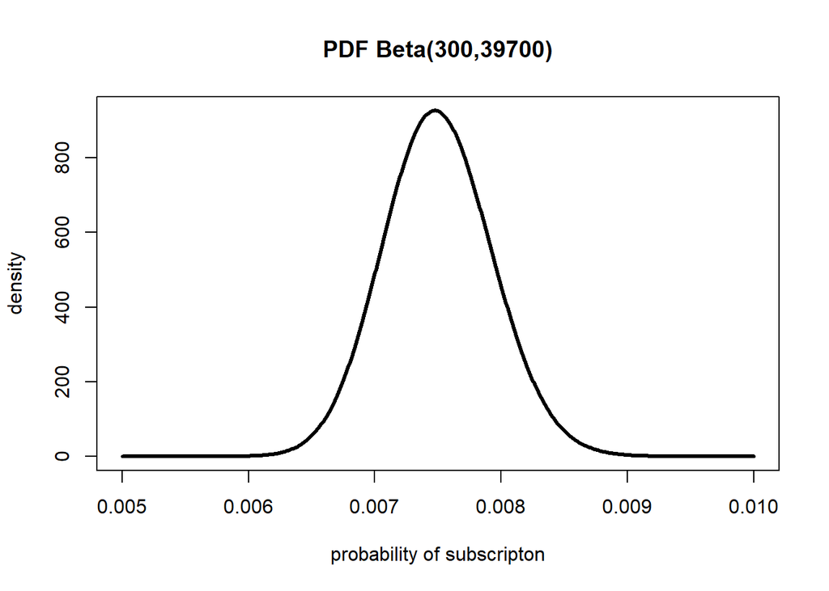

```r
xs <- seq(0.005,0.01,by=0.00001)
plot(xs,dbeta(xs,300,40000-300),type="l",lwd=3,
     ylab="density",
     xlab="probability of subscripton",
     main="PDF Beta(300,39700)")
```

## Monte Carlo Simulation

A Monte Carlo simulation is a technique that makes use of random sampling to solve a problem.  
I randomly sampled from 2 distributions where each sample is chosen based on its probability in the distribution.  
so that samples in a high-probability region will appear more frequently.

```r
n.trials <- 100000
prior.alpha <- 3
prior.beta <- 7
a.samples <- rbeta(n.trials,36+prior.alpha,114+prior.beta)
b.samples <- rbeta(n.trials,50+prior.alpha,100+prior.beta)
p.b_superior <- sum(b.samples > a.samples)/n.trials

p.b_superior
```

```
## [1] 0.95761
```

## Searching for More Hypotheses

seq() searches all possible hypotheses & picks out best 1.  
This considers every increment of 00.1between 0 & 1 as a possible hypotheses

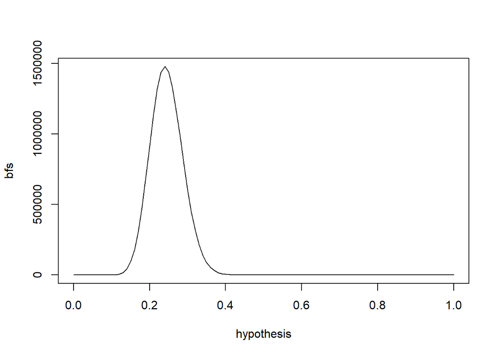

```r
dx <- 0.01
hypothesis <- seq(0,1,by=dx)
bayes.factor <- function (h_top,h_bottom) {
  ((h_top)^24*(1-h_top)^76)/((h_bottom)^24*(1-h_bottom)^76)
}
bfs <- bayes.factor(hypothesis,0.5)
plot(hypothesis,bfs,type="l")
```

```r
max(bfs)
```

```
## [1] 1478776
```

```r
hypothesis[which.max(bfs)]
```

```
## [1] 0.24
```

## Adding Prioirs to Our Likelihood Ratios

Created list of prior odds ratios for every hypothesis we have.

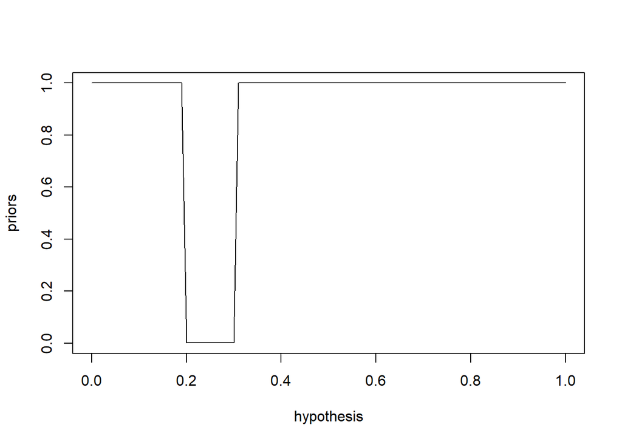

```r
priors <- ifelse(hypothesis >=0.2 & hypothesis <=0.3, 1/1000,1)
plot(hypothesis,priors,type="l")
```

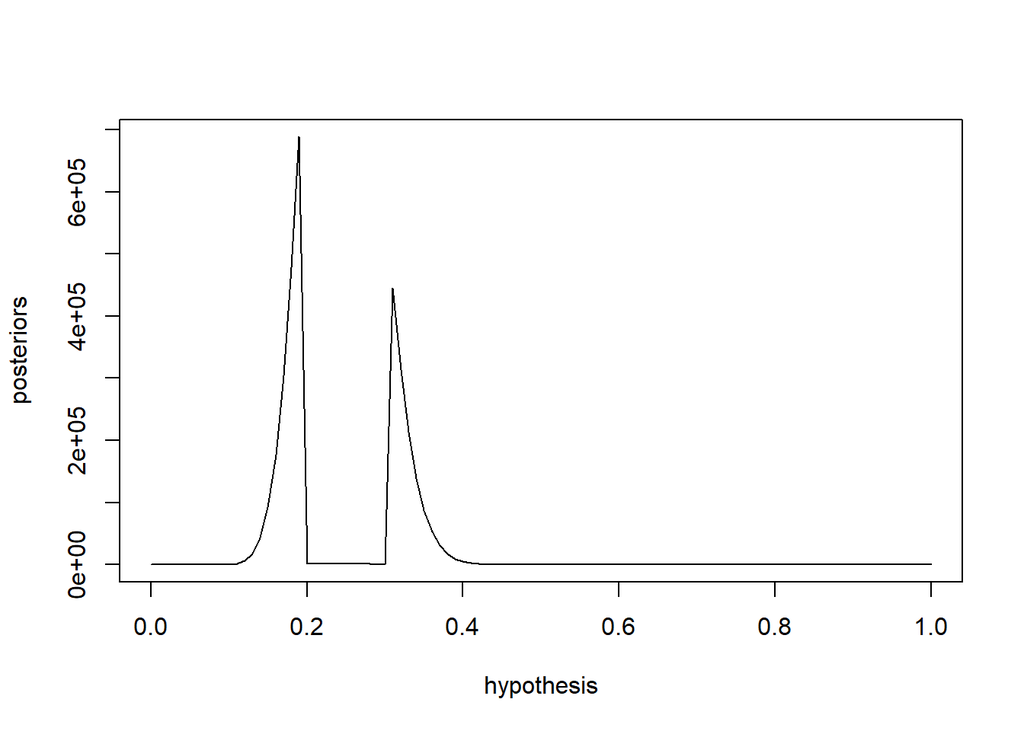

```r
posteriors <-priors*bfs
plot(hypothesis,posteriors,type="l")
```

## Building a Probabilty Distribution

A true probability distribution has sum of all possible beliefs = 1  
If not =1 we need normalize our posterior odds so they do =1. To do so divide each value in our posterior vector by sum of all values

```r
sum(posteriors)
```

```
## [1] 3140687
```

```r
p.posteriors <- posteriors/sum(posteriors)
sum(p.posteriors)
```

```
## [1] 1
```

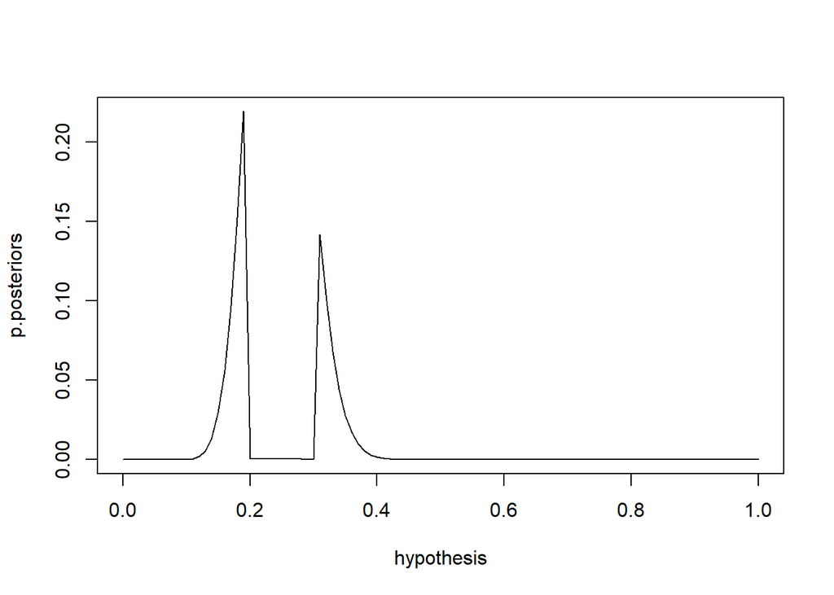

```r
plot(hypothesis,p.posteriors,type="l")
```

```r
sum(p.posteriors[which(hypothesis < 0.5)])
```

```
## [1] 0.9999995
```

```r
sum(p.posteriors*hypothesis)
```

```
## [1] 0.2402704
```

```r
hypothesis[which.max(p.posteriors)]
```

```
## [1] 0.19
```